# Practica 2 - Tipología y Ciclo de vida de datos

Maria JOsé MOrte Ruiz

Enero de 2020

# 1. Descripcion del dataset

** Por qué es importante y qué pregunta/problema pretende responder?

Por medio del análisis y exploración del dataset vamos a averiguar si se puede mplantar alguna relación entre las propiedades fisicoquímicas de los vinos analizados (datos objetivos) y su calidad (subjetiva) y definir la importancia de cada una de ellas. Las conclusiones, es determinar qué características hay que potenciar y qué procesos de producción se pueden mejorar la elaboración de nuevos vinos, ya sean de buena calidad o no.

El objetivo es comparar las características volatile acidity, Residual sugar, Chlorides, Density y pH, para determinar la calidad del vino.

# INTRODUCCION

En ésta práctica vamos a trabajar con el juego de datos de es el Red Wine Quality https://www.kaggle.com/uciml/red-wine-quality-cortez-et-al-2009. o https://archive.ics.uci.edu/ml/machine-learning-databases/wine-quality/ el cual contiene dos datasets, uno de vinos blancos y otro de vinos tintos. Ambos datasets contienen 11 atributos de entrada, correspondientes a pruebas fisioquímicas, y uno de salida: “quality”. El objetivo del análisis será por un lado construir un modelo que nos pueda predecir la calidad de un vino, y por otro, construir un modelo que nos permita clasificar un vino en un determinado tipo (tinto), segun el enunciado

# EL DATASET

El Dataset contienen los valores fisicoquímicos y sensoriales de las variantes rojas del vino portugués “Vinho Verde”. Para más detalles, consulte la referencia [Cortez et al., 2009].No hay datos sobre los tipos de uva, la marca del vino, el precio de venta del vino, etc.). Los conjuntos de datos se pueden tomar como tareas de Regresión Lineal Las clases están ordenadas y no equilibradas (por ejemplo, hay muchos más vinos normales que excelentes o malos).

Pretendo determinar qué propiedades fisicoquímicas hacen que un vino sea clasificado como “bueno”

#Instalar paquetes

```r
#install.packages(c("psych","ggplot2","car","Hmisc","corrplot"))
#install.packages("tidyverse")
#install.packages("ggplot2")
#install.packages("devtools")
#install.packages("DescTools")
#install.packages("usethis")
#install.packages("lawstat")
```

#Librarias necesarias

```r
#Librarias necesarias
library(ggplot2)
library(dplyr)
library(skimr)
library(stringr)
#library(ggthemes)
library(GGally)
library(corrplot)
library(corrgram)
library(nortest)
library(psych)
library(reshape2)
library(lawstat)

library(randomForest)



library(gridExtra)

library(pROC)

library(caret)
library(car)
library(stats)
```

# 2. Integración y selección de los datos de interés a analizar.

Este analisis nos permite comprobar que efectivamente nuestro archivo tiene 1599 registros y 12 variables. Asi mismo, podemos ver que tipo de variable es cada una. Los datos proporcionados están disponibles en CSV; el fichero proporciona en la primera linea, el nombre de los campos para facilitar la tarea de clasificación y dispone de un total de 1599 lineas de datos

# Cargo el dataset

```r
#Lectura fichero  (winequality-red.csv)
redwine<-read.csv("winequality-red.csv")
#Se muestran los datos para asegurarnos una correcta lectura de ellos
head(redwine)
```

```
##   fixed.acidity volatile.acidity citric.acid residual.sugar chlorides
## 1           7.4             0.70        0.00            1.9     0.076
## 2           7.8             0.88        0.00            2.6     0.098
## 3           7.8             0.76        0.04            2.3     0.092
## 4          11.2             0.28        0.56            1.9     0.075
## 5           7.4             0.70        0.00            1.9     0.076
## 6           7.4             0.66        0.00            1.8     0.075
##   free.sulfur.dioxide total.sulfur.dioxide density   pH sulphates alcohol
## 1                  11                   34  0.9978 3.51      0.56     9.4
## 2                  25                   67  0.9968 3.20      0.68     9.8
## 3                  15                   54  0.9970 3.26      0.65     9.8
## 4                  17                   60  0.9980 3.16      0.58     9.8
## 5                  11                   34  0.9978 3.51      0.56     9.4
## 6                  13                   40  0.9978 3.51      0.56     9.4
##   quality
## 1       5
## 2       5
## 3       5
## 4       6
## 5       5
## 6       5
```

```r
#nombre de las variable
names(redwine)
```

```
##  [1] "fixed.acidity"        "volatile.acidity"     "citric.acid"
##  [4] "residual.sugar"       "chlorides"            "free.sulfur.dioxide"
##  [7] "total.sulfur.dioxide" "density"              "pH"
## [10] "sulphates"            "alcohol"              "quality"
```

## DESCRIPCION

Las columnas disponibles son las siguientes:

**acidez fija:** La mayoría de los ácidos involucrados con el vino o fijos o no volátiles (no se evaporan fácilmente)

**acidez volátil:** la cantidad de ácido acético en el vino, que a niveles demasiado altos puede dar lugar a un sabor desagradable y vinagre

**ácido cítrico:** encontrado en pequeñas cantidades, el ácido cítrico puede agregar ‘frescura’ y sabor a los vinos

**azúcar residual:** La cantidad de azúcar restante después de que se detiene la fermentación, es raro encontrar vinos con menos de 1 gramo / litro y los vinos con más de 45 gramos / litro se consideran dulces

**cloruros:** la cantidad de sal en el vino

**dióxido de azufre:** libre la forma libre de SO2 existe en equilibrio entre SO2 molecular (como gas disuelto) y el ion bisulfito; Previene el crecimiento microbiano y la oxidación del vino.

**dióxido de azufre:** total cantidad de formas libres y ligadas de SO2; en bajas concentraciones, el SO2 es principalmente indetectable en el vino, pero a concentraciones de SO2 libres superiores a 50 ppm, el SO2 se hace evidente en la nariz y el sabor del vino

**densidad:** la densidad del agua es cercana a la del agua dependiendo del porcentaje de contenido de alcohol y azúca

**pH:** describe cuán ácido o básico es un vino en una escala de 0 (muy ácido) a 14 (muy básico); la mayoría de los vinos están entre 3-4 en la escala de pH

**sulfatos:** un aditivo para el vino que puede contribuir a los niveles de dióxido de azufre (S02), que actúa como antimicrobiano y antioxidante

**alcohol:** el porcentaje de contenido de alcohol del vino

**calidad:** variable de salida (basada en datos sensoriales, puntaje entre 0 y 10)

Es importante destacar que las primeras 11 columnas son datos objetivos obtenidos a través de métodos cientificos mientras que la última columna, se trata de un dato subjetivo y es obtenido por un metodo desconocido, clasificando entre 3 y 8 la calidad del vino.

Procedo a la carga del CSV con los siguientes parámetros generando un dataframe denominado redwine

#Crea una variable que indique si un vino es bueno o malo

```r
#AHora tiene 13 variables con la nueva
redwine$good.wine<-ifelse(redwine$quality>6,1,0)
#Se muestran los datos para asegurarnos una correcta lectura de ellos
tail(redwine)
```

```
##      fixed.acidity volatile.acidity citric.acid residual.sugar chlorides
## 1594           6.8            0.620        0.08            1.9     0.068
## 1595           6.2            0.600        0.08            2.0     0.090
## 1596           5.9            0.550        0.10            2.2     0.062
## 1597           6.3            0.510        0.13            2.3     0.076
## 1598           5.9            0.645        0.12            2.0     0.075
## 1599           6.0            0.310        0.47            3.6     0.067
##      free.sulfur.dioxide total.sulfur.dioxide density   pH sulphates alcohol
## 1594                  28                   38 0.99651 3.42      0.82     9.5
## 1595                  32                   44 0.99490 3.45      0.58    10.5
## 1596                  39                   51 0.99512 3.52      0.76    11.2
## 1597                  29                   40 0.99574 3.42      0.75    11.0
## 1598                  32                   44 0.99547 3.57      0.71    10.2
## 1599                  18                   42 0.99549 3.39      0.66    11.0
##      quality good.wine
## 1594       6         0
## 1595       5         0
## 1596       6         0
## 1597       6         0
## 1598       5         0
## 1599       6         0
```

```r
# Printem el nom i el tipus de variable
nombretipo <- sapply(redwine,class)
data.frame(Variables=names(nombretipo),Classe=as.vector(nombretipo))
```

```
##               Variables  Classe
## 1         fixed.acidity numeric
## 2      volatile.acidity numeric
## 3           citric.acid numeric
## 4        residual.sugar numeric
## 5             chlorides numeric
## 6   free.sulfur.dioxide numeric
## 7  total.sulfur.dioxide numeric
## 8               density numeric
## 9                    pH numeric
## 10            sulphates numeric
## 11              alcohol numeric
## 12              quality integer
## 13            good.wine numeric
```

#Estadsiticas Para comprobar la calidad de los datos, realizo un str nos describe el tipo de variablesy con Summary para ver el aspecto que tiene la estadistica de los datos y

```r
#Estructura de los datos
str(redwine)
```

```
## 'data.frame':    1599 obs. of  13 variables:
##  $ fixed.acidity       : num  7.4 7.8 7.8 11.2 7.4 7.4 7.9 7.3 7.8 7.5 ...
##  $ volatile.acidity    : num  0.7 0.88 0.76 0.28 0.7 0.66 0.6 0.65 0.58 0.5 ...
##  $ citric.acid         : num  0 0 0.04 0.56 0 0 0.06 0 0.02 0.36 ...
##  $ residual.sugar      : num  1.9 2.6 2.3 1.9 1.9 1.8 1.6 1.2 2 6.1 ...
##  $ chlorides           : num  0.076 0.098 0.092 0.075 0.076 0.075 0.069 0.065 0.073 0.071 ...
##  $ free.sulfur.dioxide : num  11 25 15 17 11 13 15 15 9 17 ...
##  $ total.sulfur.dioxide: num  34 67 54 60 34 40 59 21 18 102 ...
##  $ density             : num  0.998 0.997 0.997 0.998 0.998 ...
##  $ pH                  : num  3.51 3.2 3.26 3.16 3.51 3.51 3.3 3.39 3.36 3.35 ...
##  $ sulphates           : num  0.56 0.68 0.65 0.58 0.56 0.56 0.46 0.47 0.57 0.8 ...
##  $ alcohol             : num  9.4 9.8 9.8 9.8 9.4 9.4 9.4 10 9.5 10.5 ...
##  $ quality             : int  5 5 5 6 5 5 5 7 7 5 ...
##  $ good.wine           : num  0 0 0 0 0 0 0 1 1 0 ...
```

```r
# Es una función genérica utilizada para  resúmenes de resultados, de varias funciones.
# Muestra la media, mediana, cuartiles, valor mínimo y valor máximo, para variables cuantitativas y la frecuencia absoluta para variables cualitativas.

summary(redwine)
```

```
##  fixed.acidity   volatile.acidity  citric.acid    residual.sugar
##  Min.   : 4.60   Min.   :0.1200   Min.   :0.000   Min.   : 0.900
##  1st Qu.: 7.10   1st Qu.:0.3900   1st Qu.:0.090   1st Qu.: 1.900
##  Median : 7.90   Median :0.5200   Median :0.260   Median : 2.200
##  Mean   : 8.32   Mean   :0.5278   Mean   :0.271   Mean   : 2.539
##  3rd Qu.: 9.20   3rd Qu.:0.6400   3rd Qu.:0.420   3rd Qu.: 2.600
##  Max.   :15.90   Max.   :1.5800   Max.   :1.000   Max.   :15.500
##    chlorides       free.sulfur.dioxide total.sulfur.dioxide    density
##  Min.   :0.01200   Min.   : 1.00       Min.   :  6.00       Min.   :0.9901
##  1st Qu.:0.07000   1st Qu.: 7.00       1st Qu.: 22.00       1st Qu.:0.9956
##  Median :0.07900   Median :14.00       Median : 38.00       Median :0.9968
##  Mean   :0.08747   Mean   :15.87       Mean   : 46.47       Mean   :0.9967
##  3rd Qu.:0.09000   3rd Qu.:21.00       3rd Qu.: 62.00       3rd Qu.:0.9978
##  Max.   :0.61100   Max.   :72.00       Max.   :289.00       Max.   :1.0037
##        pH          sulphates         alcohol         quality
##  Min.   :2.740   Min.   :0.3300   Min.   : 8.40   Min.   :3.000
##  1st Qu.:3.210   1st Qu.:0.5500   1st Qu.: 9.50   1st Qu.:5.000
##  Median :3.310   Median :0.6200   Median :10.20   Median :6.000
##  Mean   :3.311   Mean   :0.6581   Mean   :10.42   Mean   :5.636
##  3rd Qu.:3.400   3rd Qu.:0.7300   3rd Qu.:11.10   3rd Qu.:6.000
##  Max.   :4.010   Max.   :2.0000   Max.   :14.90   Max.   :8.000
##    good.wine
##  Min.   :0.0000
##  1st Qu.:0.0000
##  Median :0.0000
##  Mean   :0.1357
##  3rd Qu.:0.0000
##  Max.   :1.0000
```

```r
# La distribución de frecuencia de los niveles del factor
table(redwine$quality)
```

```
##
##   3   4   5   6   7   8
##  10  53 681 638 199  18
```

Observamos una concentración en los valores 5 y 6 de calidad; con valores entre 3 y 8, en el summary, vemos como valor medio 5.636 como resumen del análisis utilizamos la función skimr Realizmao estudio

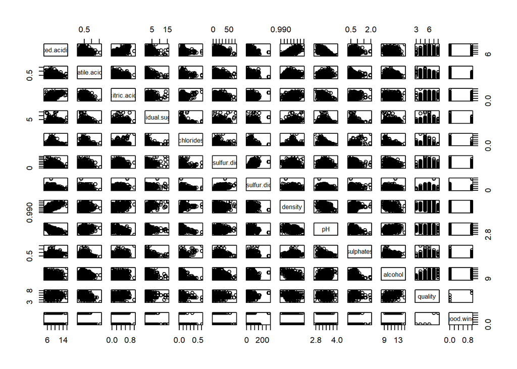

```r
# Graficas  del dataset
plot(redwine)
```

```r
# Resumen de estadisticas
skim(redwine)
```

Data summary

| Name | redwine |
| --- | --- |
| Number of rows | 1599 |
| Number of columns | 13 |
| _______________________ |  |
| Column type frequency: |  |
| numeric | 13 |
| ________________________ |  |
| Group variables | None |

**Variable type: numeric**

[output not shown]

NOTA: Ms adelante de este documento se adjuntan gráficas relativas a la distribución de los valores de los diferentes atributos en formato boxplot y histog

# 3. LIMPIEZA DE DATOS

## . ¿Los datos contienen ceros o elementos vacíos? ¿Cómo gestionarías cada uno de estos casos?

El dataframe no tiene campos vacios ni nulos, es un buen dataset desde el punto de vista de limpieza.

### VALORES NULOS

Uno de los primeros pasos cuando se trabaja con datos, es observar si las variables tienen valores perdidos o nulos. Esto significa, que por alguna razon no se pude obtener o registrar el valor.

Si bien, lo ideal es que nunca falten ningun dato, lo cierto es que en la realidad eso pocas veces pasa, por lo que se deben de aplicar tecnicas para poder estimar esos valores que no estan disponibles.

Lo primero que se hara, es verificar que no existan valores perdidos en el conjunto de datos a analizar.

El dataset no tiene elementos vacios, lo podemos comprobar con el siguiente comando. HAy que tenr en cuenta que comúnmente, se utilizan los ceros como centinela para indicar la ausencia de ciertos valores. Vamos a proceder a conocer a continuación qué campos contienen elementos con valores ceros o elementos vacíos

```r
sapply(redwine, function(x) sum(length(which(is.na(x)))))
```

```
##        fixed.acidity     volatile.acidity          citric.acid
##                    0                    0                    0
##       residual.sugar            chlorides  free.sulfur.dioxide
##                    0                    0                    0
## total.sulfur.dioxide              density                   pH
##                    0                    0                    0
##            sulphates              alcohol              quality
##                    0                    0                    0
##            good.wine
##                    0
```

```r
#colSums(is.na(redwine))
```

```r
## Verificar en que columnas hay valores cero
lapply(redwine, function(x) sum(x==0))
```

```
## $fixed.acidity
## [1] 0
##
## $volatile.acidity
## [1] 0
##
## $citric.acid
## [1] 132
##
## $residual.sugar
## [1] 0
##
## $chlorides
## [1] 0
##
## $free.sulfur.dioxide
## [1] 0
##
## $total.sulfur.dioxide
## [1] 0
##
## $density
## [1] 0
##
## $pH
## [1] 0
##
## $sulphates
## [1] 0
##
## $alcohol
## [1] 0
##
## $quality
## [1] 0
##
## $good.wine
## [1] 1382
```

```r
#sum(is.na(redwine))
```

Podemos ver que no hay problema en un caso **good.wine** nuestra varible de uso, es de usode clasificacion por asi decirlo, y en caso de citric.acid con 132 es un valor que pude etar permitido para eata variable, por lo tanto son valores queno decartamos sino buenos Solo el campo **citric.acid** tiene valores cero. Podemos ver en el siguiente enlace (http://waterhouse.ucdavis.edu/whats-in-wine/fixed-acidity) la concentración de ácido cítrico puede ser entre 0 y 500 mg/L, por lo tanto, podemos dar esos valores como buenos.

### Identificación y tratamiento de valores extremos.

Vamos a comprobar los Outlier que tiene las variables con el comando

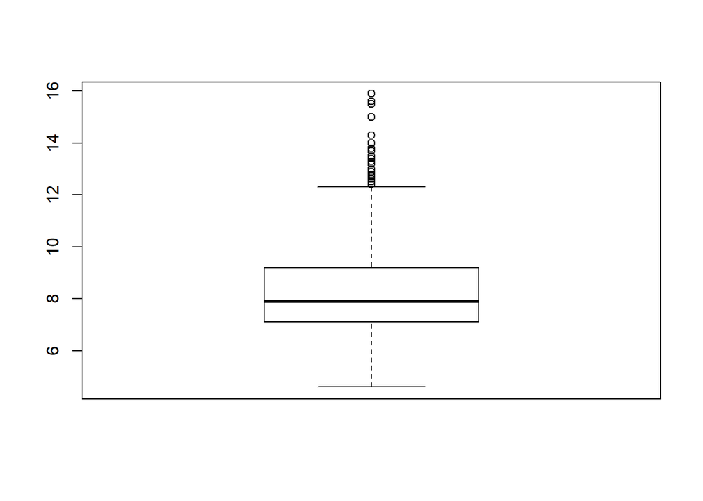

```r
boxplot(redwine$fixed.acidity )
```

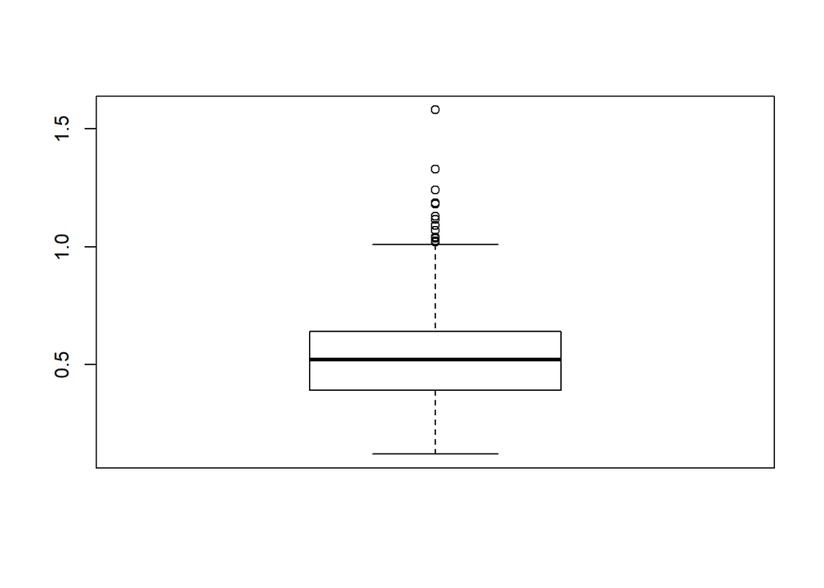

```r
boxplot(redwine$volatile.acidity)
```

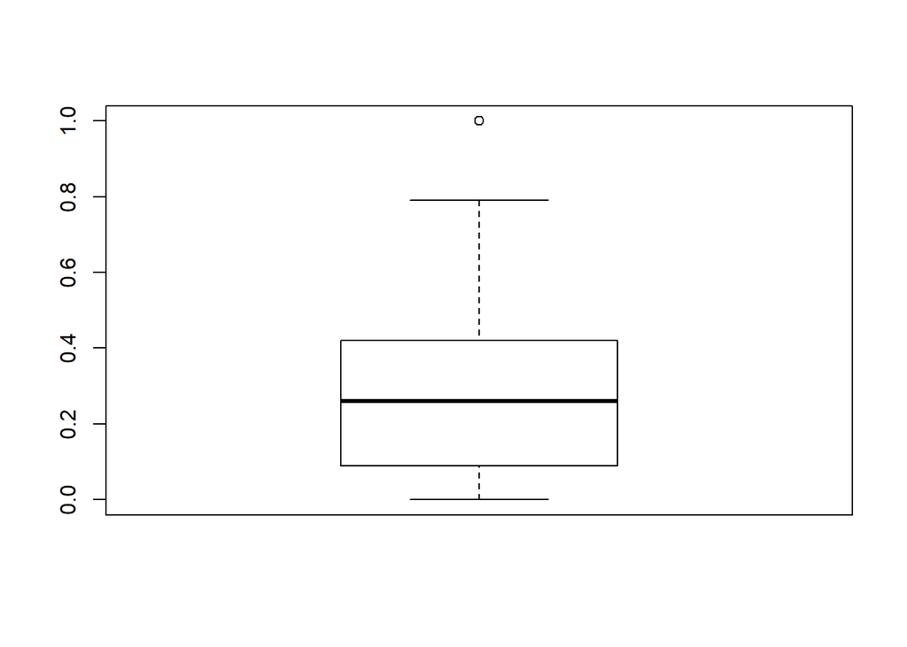

```r
boxplot(redwine$citric.acid)
```

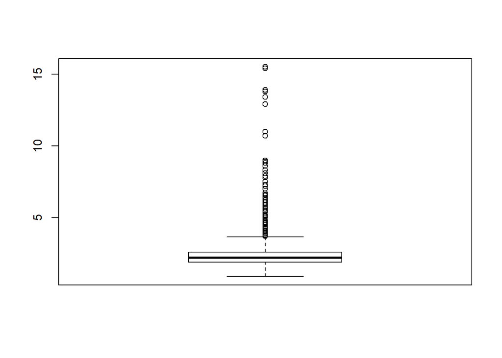

```r
boxplot(redwine$residual.sugar)
```

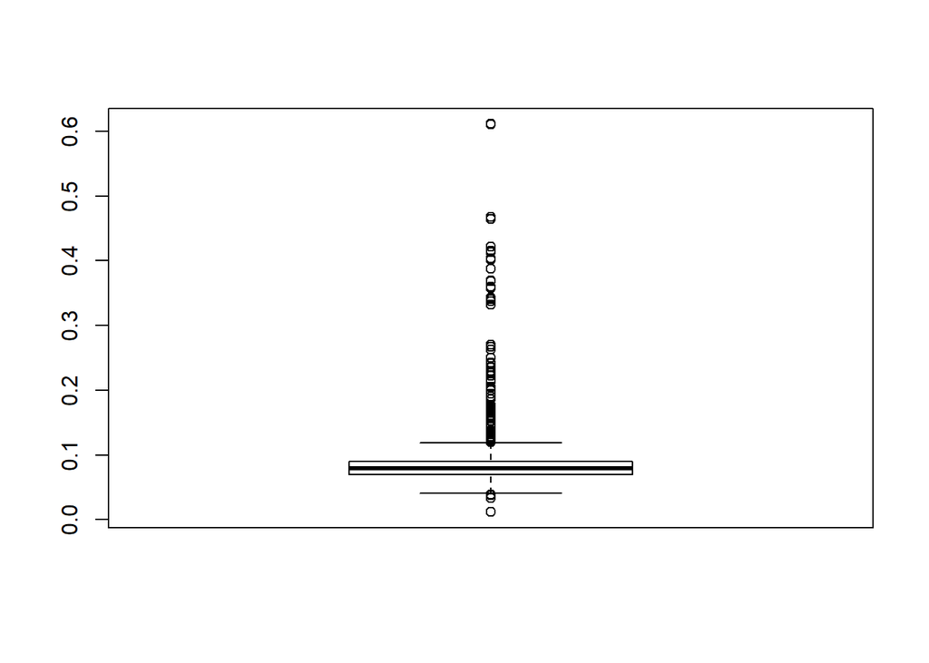

```r
boxplot(redwine$chlorides)
```

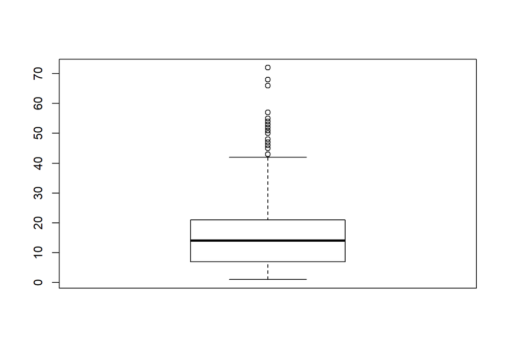

```r
boxplot(redwine$free.sulfur.dioxide)
```

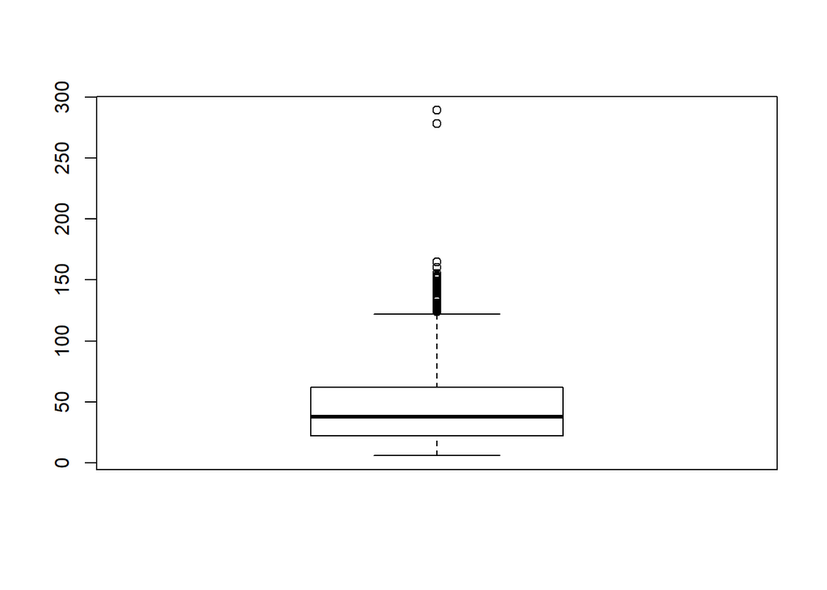

```r
boxplot(redwine$total.sulfur.dioxide)
```

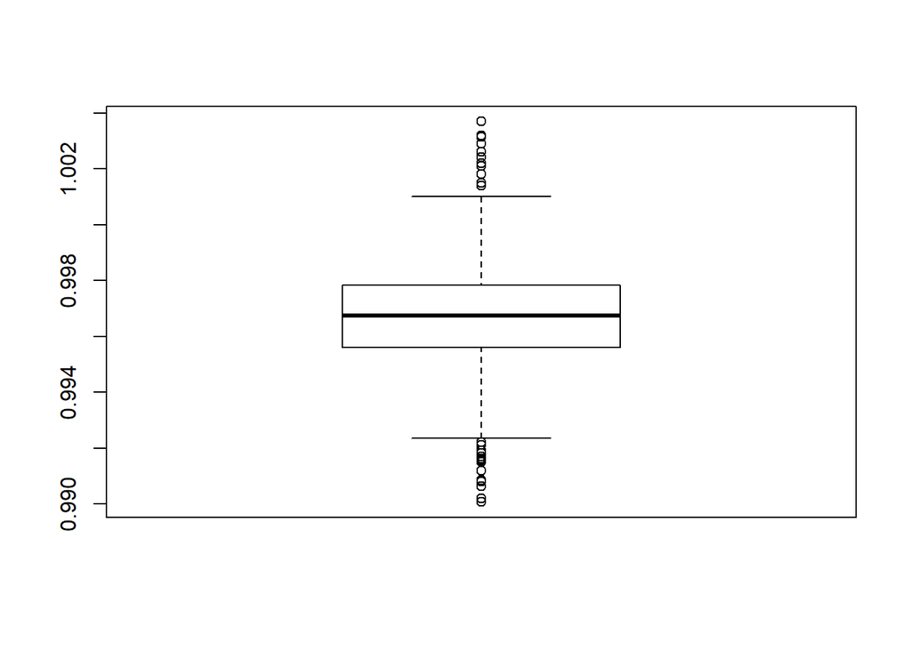

```r
boxplot(redwine$density)
```

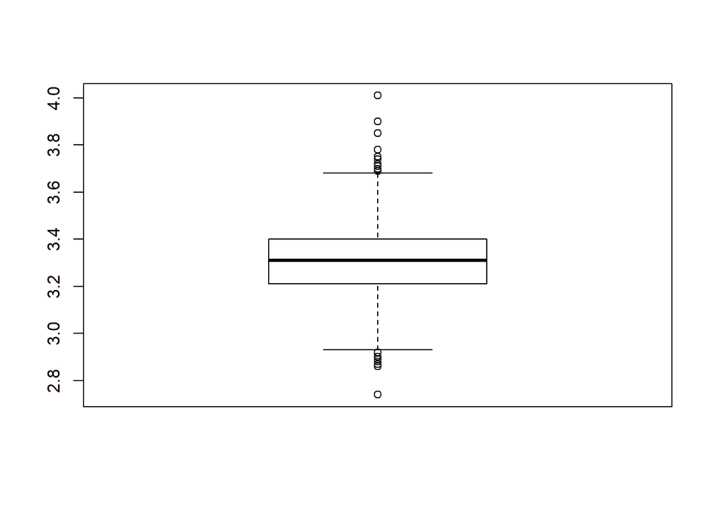

```r
boxplot(redwine$pH)
```

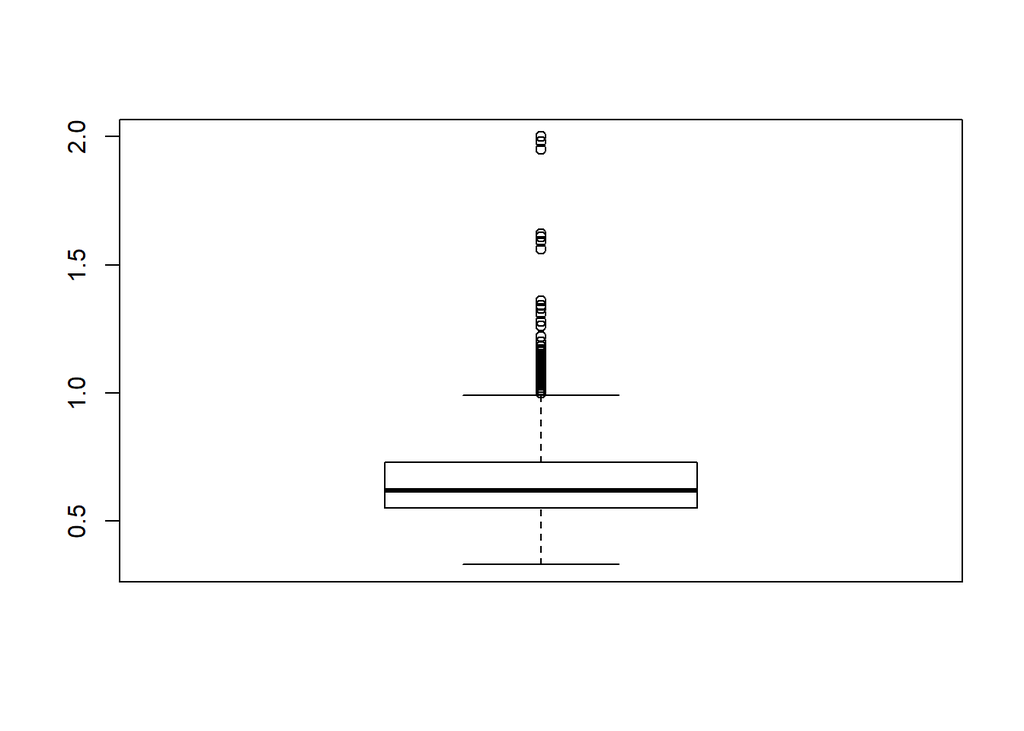

```r
boxplot(redwine$sulphates)
```

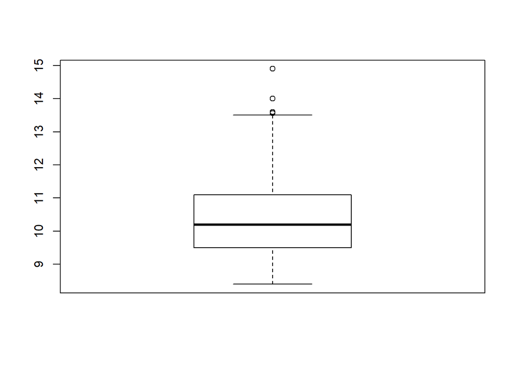

```r
boxplot(redwine$alcohol)
```

En esta variable encontramos una serie de valores extremos a la media los cuales son necesarios estudiar. En este caso en particular, considero necesario dejar los valores atípicos de los datos objetivos como son los de los valores fisicoquímicos obtenidos Otro caso es el Quality, puesto que es subjetivo, tampoco conocemos el margen de error que puede tener la decisión de haberlo marcado con el valor 8.

Para la variable a buscar obtenemos los siguients outlers

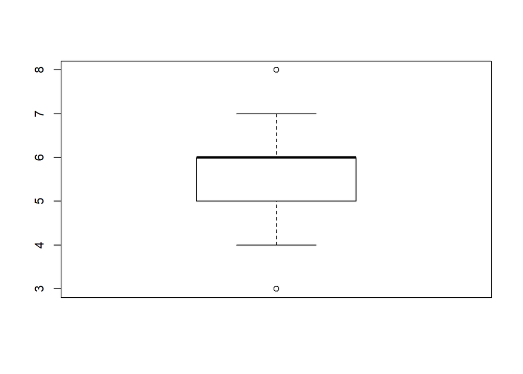

```r
boxplot(redwine$quality)
```

```r
fivenum(redwine$quality)
```

```
## [1] 3 5 6 6 8
```

- minimum = 3
- lower-hinge = 5
- median = 6
- upper-hinge = 6
- maximum = 8

La conclusión es que un gran número de valores se concentran alrededor del 5 y 6 de calidad (el valor de la media y mediana están ente estos dos valores)

Se dice que un valor extremo se puede describir como una observación que se desvía tanto de otros observaciones como para despertar sospechas de que fue generado por un mecanismo diferente.

Como punto de partida, podemos considerar que aquellas observaciones alejadas 3 o más desviaciones estándar de la media de la muestra son susceptibles de ser valores extremos, salvo que la muestra sea particularmente pequeña. Esta valores extremos son un caso particular de los valores que, convencionalmente y de manera generalizada, se conocen como outliers y que por definición son aquellos valores que están situados en: • una distancia superior a 1,5 veces el rango interquartíl.lic por sobre el 3er cuartil • una distancia inferior a 1,5 veces el rango interquartíl.lic por debajo del 1er cuartil Usaremos esta última definición (configuración por defecto del parámetro coef de la función boxplot.stats) para el cálculo de los valores aípics

```r
c <- names(redwine)
total_vatipicos<- 0
for (i in 1:ncol(redwine))
{
cat(" \n")
a <- boxplot.stats(redwine[, i],)$out
cat("**Atributos '",c[i],"'** \n", sep = '')
cat("*Num. valores atipicos : ", length(a), "* \n", sep = '')
cat(sort(a), " \n")
total_vatipicos <- total_vatipicos + length(a)
}
```

```
##
## **Atributos 'fixed.acidity'**
## *Num. valores atipicos : 49*
## 12.4 12.4 12.4 12.4 12.5 12.5 12.5 12.5 12.5 12.5 12.5 12.6 12.6 12.6 12.6 12.7 12.7 12.7 12.7 12.8 12.8 12.8 12.8 12.8 12.9 12.9 13 13 13 13.2 13.2 13.2 13.3 13.3 13.3 13.4 13.5 13.7 13.7 13.8 14 14.3 15 15 15.5 15.5 15.6 15.6 15.9
##
## **Atributos 'volatile.acidity'**
## *Num. valores atipicos : 19*
## 1.02 1.02 1.02 1.02 1.025 1.035 1.04 1.04 1.04 1.07 1.09 1.115 1.13 1.18 1.185 1.24 1.33 1.33 1.58
##
## **Atributos 'citric.acid'**
## *Num. valores atipicos : 1*
## 1
##
## **Atributos 'residual.sugar'**
## *Num. valores atipicos : 155*
## 3.7 3.7 3.7 3.7 3.75 3.8 3.8 3.8 3.8 3.8 3.8 3.8 3.8 3.9 3.9 3.9 3.9 3.9 3.9 4 4 4 4 4 4 4 4 4 4 4 4.1 4.1 4.1 4.1 4.1 4.1 4.2 4.2 4.2 4.2 4.2 4.25 4.3 4.3 4.3 4.3 4.3 4.3 4.3 4.3 4.4 4.4 4.4 4.4 4.5 4.5 4.5 4.5 4.6 4.6 4.6 4.6 4.6 4.6 4.65 4.65 4.7 4.8 4.8 4.8 5 5.1 5.1 5.1 5.1 5.1 5.15 5.2 5.2 …
##
## **Atributos 'chlorides'**
## *Num. valores atipicos : 112*
## 0.012 0.012 0.034 0.038 0.038 0.039 0.039 0.039 0.039 0.12 0.12 0.12 0.121 0.121 0.122 0.122 0.122 0.122 0.122 0.122 0.122 0.123 0.123 0.123 0.123 0.123 0.123 0.124 0.124 0.124 0.125 0.126 0.127 0.128 0.132 0.132 0.132 0.132 0.136 0.137 0.143 0.145 0.146 0.147 0.148 0.152 0.152 0.153 0.157 0.157 …
##
## **Atributos 'free.sulfur.dioxide'**
## *Num. valores atipicos : 30*
## 43 43 43 45 45 45 46 47 48 48 48 48 50 50 51 51 51 51 52 52 52 53 54 55 55 57 66 68 68 72
##
## **Atributos 'total.sulfur.dioxide'**
## *Num. valores atipicos : 55*
## 124 124 124 125 125 126 127 127 128 128 129 129 129 130 131 131 131 133 133 133 134 134 135 135 136 136 139 140 141 141 141 142 143 143 144 144 144 145 145 145 147 147 147 148 148 149 151 151 152 153 155 160 165 278 289
##
## **Atributos 'density'**
## *Num. valores atipicos : 45*
## 0.99007 0.99007 0.9902 0.99064 0.99064 0.9908 0.99084 0.9912 0.9915 0.99154 0.99157 0.9916 0.9916 0.99162 0.9917 0.99182 0.99182 0.99191 0.9921 0.9922 0.9922 1.0014 1.0014 1.0014 1.0014 1.0014 1.0014 1.0015 1.0015 1.0018 1.0021 1.0021 1.0022 1.0022 1.00242 1.00242 1.0026 1.0026 1.00289 1.00315 1.…
##
## **Atributos 'pH'**
## *Num. valores atipicos : 35*
## 2.74 2.86 2.87 2.88 2.88 2.89 2.89 2.89 2.89 2.9 2.92 2.92 2.92 2.92 3.69 3.69 3.69 3.69 3.7 3.71 3.71 3.71 3.71 3.72 3.72 3.72 3.74 3.75 3.78 3.78 3.85 3.9 3.9 4.01 4.01
##
## **Atributos 'sulphates'**
## *Num. valores atipicos : 59*
## 1 1.01 1.02 1.02 1.02 1.03 1.03 1.04 1.04 1.05 1.05 1.05 1.06 1.06 1.06 1.06 1.07 1.07 1.08 1.08 1.08 1.09 1.1 1.1 1.11 1.12 1.13 1.13 1.14 1.14 1.15 1.16 1.17 1.17 1.17 1.17 1.17 1.18 1.18 1.18 1.2 1.22 1.26 1.28 1.28 1.31 1.33 1.34 1.36 1.36 1.36 1.56 1.59 1.61 1.62 1.95 1.95 1.98 2
##
## **Atributos 'alcohol'**
## *Num. valores atipicos : 13*
## 13.56667 13.6 13.6 13.6 13.6 14 14 14 14 14 14 14 14.9
##
## **Atributos 'quality'**
## *Num. valores atipicos : 28*
## 3 3 3 3 3 3 3 3 3 3 8 8 8 8 8 8 8 8 8 8 8 8 8 8 8 8 8 8
##
## **Atributos 'good.wine'**
## *Num. valores atipicos : 217*
## 1 1 1 1 1 1 1 1 1 1 1 1 1 1 1 1 1 1 1 1 1 1 1 1 1 1 1 1 1 1 1 1 1 1 1 1 1 1 1 1 1 1 1 1 1 1 1 1 1 1 1 1 1 1 1 1 1 1 1 1 1 1 1 1 1 1 1 1 1 1 1 1 1 1 1 1 1 1 1 1 1 1 1 1 1 1 1 1 1 1 1 1 1 1 1 1 1 1 1 1 1 1 1 1 1 1 1 1 1 1 1 1 1 1 1 1 1 1 1 1 1 1 1 1 1 1 1 1 1 1 1 1 1 1 1 1 1 1 1 1 1 1 1 1 1 1 1 1 1…
```

## Grafico

```r
#Distancia de Mahalanobis
#Su utilidad radica en que es una forma de determinar la similitud entre dos variables aleatorias multidimensionales
options(repr.plot.width=6, repr.plot.height=4)
#Calsulamso la distancia de Mahalanobis
mahaladistancia <- mahalanobis(redwine[, c(1:11)], colMeans(redwine[, c(1:11)]), cov(redwine[, c(1:11)]))
# Estadistica  basica de la distancia de Mahalanobis- mahaladistncia
summary(mahaladistancia)
```

```
##    Min. 1st Qu.  Median    Mean 3rd Qu.    Max.
##   1.092   5.120   7.738  10.993  12.172 155.546
```

```r
# Rango intercuartílico
iqr <- IQR(mahaladistancia)
iqr
```

```
## [1] 7.052017
```

```r
## [1] 7.052017
```

```r
# Umbral
Umbral <- IQR(mahaladistancia)*(1.5) + summary(mahaladistancia)[[5]] # 3er quartil
Umbral
```

```
## [1] 22.74971
```

```r
#[1] 22.74971
```

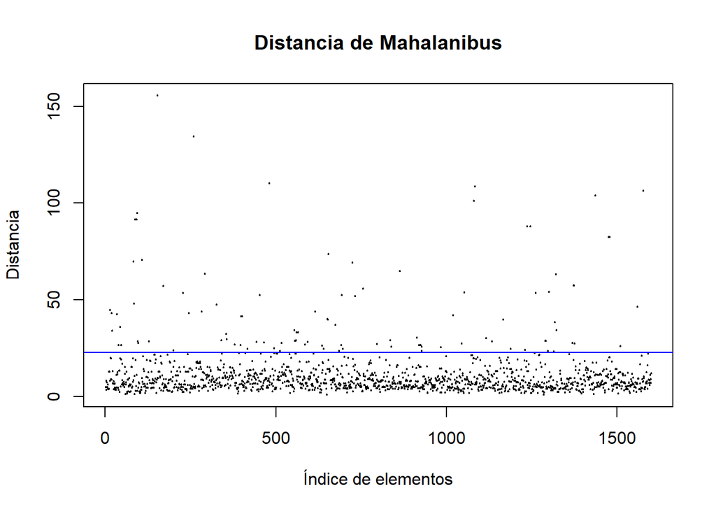

```r
# Representación gráfica
plot(mahaladistancia, pch=1, cex=.2, main="Distancia de Mahalanibus",
xlab = "Índice de elementos", ylab="Distancia")
#liena de corte
abline(h = Umbral, col="blue")
```

```r
# Nombre valores atipicos
vp <- length(boxplot.stats(mahaladistancia)$out)
vp
```

```
## [1] 110
```

```r
#[1] 110
```

```r
redwine$mahaladistncia <- NULL
```

```r
#Se guardan los datos en un nuevo archivo csv
write.csv(redwine, "redwine.csv")
```

# 4 Análisis DE DATOS

### Selccionde lso datos

Vamos a usar tods lso atributos, etudairemso la homogeneidad de la varianza, discretizar la variable quality en una nueva variable clase, cualitativa, que contendrá 3 valores posibles (Malo, Normal o Bueno) relativas a la valoración del vino Normalidad Planteamos el contraste de hipotesis par saber si los atribitos siguen una distribucion normal con uan significacion α del 0.05.

• H0: La muestra de tamaño n sigue una distribución Normal • H1: La muestra de tamaño n NO sigue una distribución Normal Este contraste lo llevaremos a cabo con el test de normalidad de Shapiro-Wilk para cada uno de los atributos. Si el p-valor obtenido para cada atributo es menor al nivel de significación α (<0,05), rechazaremos la hipótesis nul.la (H0) y afirmaremos que la muestra NO sigue una distribución normal

```r
# Normalitat
for (i in 1:ncol(redwine))
{
  cat("Atribut '",c[i],"', ", sep = '')
  pvalor <- shapiro.test(redwine[, i])[["p.value"]]
  cat("p-valor '", pvalor,"'\n", sep = '')
}
```

```
## Atribut 'fixed.acidity', p-valor '1.525012e-24'
## Atribut 'volatile.acidity', p-valor '2.692935e-16'
## Atribut 'citric.acid', p-valor '1.021932e-21'
## Atribut 'residual.sugar', p-valor '1.020162e-52'
## Atribut 'chlorides', p-valor '1.179056e-55'
## Atribut 'free.sulfur.dioxide', p-valor '7.694597e-31'
## Atribut 'total.sulfur.dioxide', p-valor '3.573451e-34'
## Atribut 'density', p-valor '1.936053e-08'
## Atribut 'pH', p-valor '1.712237e-06'
## Atribut 'sulphates', p-valor '5.82314e-38'
## Atribut 'alcohol', p-valor '6.644057e-27'
## Atribut 'quality', p-valor '9.515085e-36'
## Atribut 'good.wine', p-valor '3.726209e-58'
```

Observamso que no seiguen una distribucion normañ Aplicaremso la homogeneidad de la varianza aplicando también un contraste de hipótesis con un nivel de significación α del 0.05. Para ello, tal y como se he dicho hemos discretizado la variable quality en una nueva variable cualitativa clase, cualitativa, que contendrá 3 valores posibles (Malo, Normal o Bueno) relativas a la valoración del vino.

Aplicaremos la homogeneidad comparando las varianzas de las muestras de vinos agrupados por este nuevo atributo clase • H0: Las varianzas poblacionales son iguales (Homoscedasticidad): • H1: Las varianzas poblacionales son diferentes (heteroscedasticidad) Este contraste lo llevaremos a cabo mediante deltest de Levene Si el p-valor obtenido es menor que el nivel de significación α (<0,05) rechazaremos la hipótesis nul.la (H0) y afirmaremos que las varianzas poblacionales son diferentes (heteroscedasticidad). De lo contrario, no podremos rechazar la hipótesis nul.la H0

```r
# Homogeneitat de les variances
redwine2 <- redwine
redwine2$classe <- 0
idx <- which(redwine2$quality < 5)
redwine2$classe[idx] <- "Dolent"
idx <- which(redwine2$quality >= 5 & redwine2$quality <= 6)
redwine2$classe[idx] <- "Normal"
idx <- which(redwine2$quality >= 7)
redwine2$classe[idx] <- "Bo"
redwine2$quality <- NULL
redwine2$classe <- as.factor(redwine2$classe)
table(redwine2$classe)
```

```
##
##     Bo Dolent Normal
##    217     63   1319
```

```r
# El test de Levene
leveneTest(redwine2$alcohol,redwine2$classe)
```

```
## Levene's Test for Homogeneity of Variance (center = median)
##         Df F value Pr(>F)
## group    2  0.7375 0.4785
##       1596
```

Conclusion: Como el p-valor (0.4785) es mayor que el nivel de signifació α (0.05), no podemos rechazar la hipótesis nula H0 que las varianzas poblacionales son iguales y por lo tanto, podemos afirmar que hay homoscedasticidad

## Comparar dos grupos de daros:

Queremos ver si hay relacion entre las propiedades fisicoquímicas de los vinos analizados (datos objetivos) y su calidad (Valoración subjetiva) y determinar la importancia de cada una de ellas.

Para llevarlo a cabo, realizaremos 3 pruebas estadísticas La matriz de correlación entre los diferentes atributos, hallarla Reducir la cardinalidad aplicando un algoritmo de PCA Modelos de regresión lineal para ver si estos cuentan o no la calidad del vino en función del resto de atributos y si el modelo fomenta dudas

### Matriz de correlacion

Dos graficas que representa la ralcion directa o inveras de lso atributos del dataset

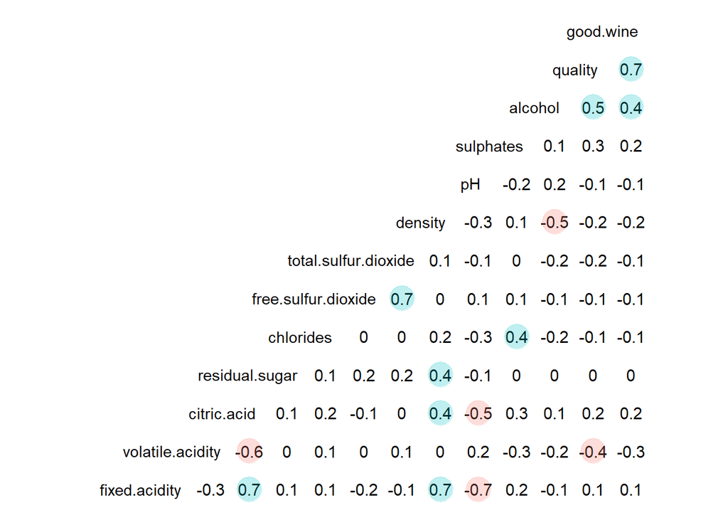

```r
# Grafico
options(repr.plot.width=4, repr.plot.height=3)
ggcorr(redwine, geom = "blank", label = TRUE,
hjust = 0.9, layout.exp = 2) +
geom_point(size = 8, aes(color = coefficient > 0,
alpha = abs(coefficient) > 0.35)) +
scale_alpha_manual(values = c("TRUE" = 0.25, "FALSE" = 0)) +
guides(color = FALSE, alpha = FALSE)
```

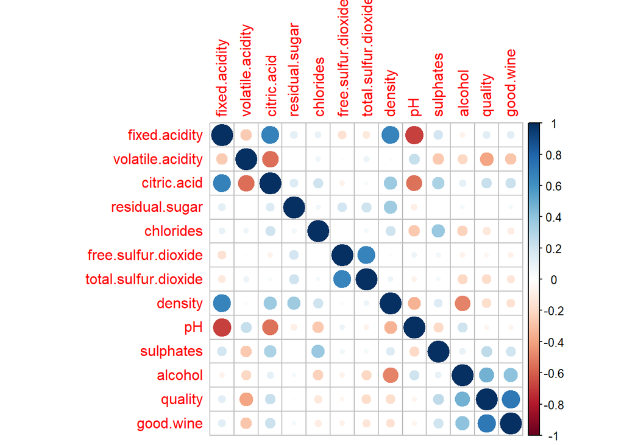

```r
# Visualizacion grafica de una matriz a color

cor_redwine<-cor(redwine)
#cor_redwine
library(corrplot)
corrplot(cor_redwine,method = "circle")
```

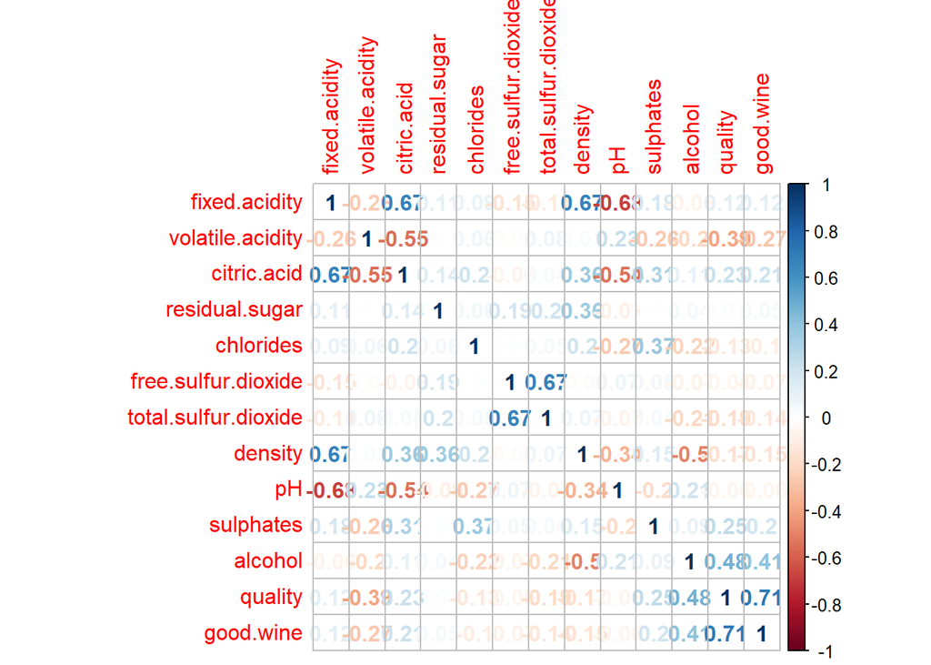

```r
corrplot(cor_redwine,method = "number")
```

Observaciones • La calidad (**quality**)del vino parece estar principalmente relacionada con los niveles de alcohol (**alcohol**), de manera directa y con la concentración de ácido acético (**volatile.acidity**), de manera **inversa**. • El% de alcohol de un vino (**alcohol**) está inversamente relacionado con su densidad (**density**) • El valor de pH (**pH**) está inversa y significativamente relacionado con atributos que tienen que ver con la acidez (**citric.acid** y **fixed.acidity**) • La densidad (**density**) es la propiedad con un *mayor* número de correlaciones con otros atributos (directa o inversamente): **alcohol**, **residual.sugar**, **citric.acid** y **fixed.acidity** • Los atributos que miden sustancias similares (**total.sulfur.dioxide** y **free.sulfur.dioxide**, por un lado y **citric.acid**, **volatile.acidity** y **fixed.acidity**, por el otro) están fuertemente correlacionades (Directa o inversamente), como era de esperar y ya habíamos enunciado. •Para terminar, el atributo **fixed.acidity** es la que está más fuertemente correlacionada (directa o inversamente) con otros atributos: ""citric.acid**,** density** y **pH** Hay atributos que parecen mejores candidatos a ser explicados con métodos de regresión lineal que a la calidad (**quality**)

### PCA

DESpes de la correlación que hay entre los diferentes atributos, aunque su cardinalidad NO es muy alta, parece que NO son necesarios todos atributos para determinar la calidad del vino. Vamos a ver que el atributo **quality** sólo está muy relacionado con los atributos **alcohol** y **volatile.acidity** APlicamso PCA para reducir la cardinalidad del conjunto, para encontrar qué atributos son significativos

```r
# Elegimos 'quality' y aplicamos el PCA
redwine.pca <- prcomp(redwine[,1:11], scale. = TRUE)
```

```r
summary(redwine.pca)
```

```
## Importance of components:
##                           PC1    PC2    PC3    PC4     PC5     PC6     PC7
## Standard deviation     1.7604 1.3878 1.2452 1.1015 0.97943 0.81216 0.76406
## Proportion of Variance 0.2817 0.1751 0.1410 0.1103 0.08721 0.05996 0.05307
## Cumulative Proportion  0.2817 0.4568 0.5978 0.7081 0.79528 0.85525 0.90832
##                            PC8     PC9    PC10    PC11
## Standard deviation     0.65035 0.58706 0.42583 0.24405
## Proportion of Variance 0.03845 0.03133 0.01648 0.00541
## Cumulative Proportion  0.94677 0.97810 0.99459 1.00000
```

Se ve que que hace falat 7 atributos apr explciar la varianza al 90%

```r
#
redwine.pca$rotation
```

```
##                              PC1          PC2         PC3          PC4
## fixed.acidity         0.48931422 -0.110502738  0.12330157 -0.229617370
## volatile.acidity     -0.23858436  0.274930480  0.44996253  0.078959783
## citric.acid           0.46363166 -0.151791356 -0.23824707 -0.079418256
## residual.sugar        0.14610715  0.272080238 -0.10128338 -0.372792562
## chlorides             0.21224658  0.148051555  0.09261383  0.666194756
## free.sulfur.dioxide  -0.03615752  0.513566812 -0.42879287 -0.043537818
## total.sulfur.dioxide  0.02357485  0.569486959 -0.32241450 -0.034577115
## density               0.39535301  0.233575490  0.33887135 -0.174499758
## pH                   -0.43851962  0.006710793 -0.05769735 -0.003787746
## sulphates             0.24292133 -0.037553916 -0.27978615  0.550872362
## alcohol              -0.11323206 -0.386180959 -0.47167322 -0.122181088
##                              PC5         PC6         PC7         PC8
## fixed.acidity         0.08261366 -0.10147858  0.35022736 -0.17759545
## volatile.acidity     -0.21873452 -0.41144893  0.53373510 -0.07877531
## citric.acid           0.05857268 -0.06959338 -0.10549701 -0.37751558
## residual.sugar       -0.73214429 -0.04915555 -0.29066341  0.29984469
## chlorides            -0.24650090 -0.30433857 -0.37041337 -0.35700936
## free.sulfur.dioxide   0.15915198  0.01400021  0.11659611 -0.20478050
## total.sulfur.dioxide  0.22246456 -0.13630755  0.09366237  0.01903597
## density              -0.15707671  0.39115230  0.17048116 -0.23922267
## pH                   -0.26752977  0.52211645  0.02513762 -0.56139075
## sulphates            -0.22596222  0.38126343  0.44746911  0.37460432
## alcohol              -0.35068141 -0.36164504  0.32765090 -0.21762556
##                               PC9        PC10         PC11
## fixed.acidity         0.194020908  0.24952314  0.639691452
## volatile.acidity     -0.129110301 -0.36592473  0.002388597
## citric.acid          -0.381449669 -0.62167708 -0.070910304
## residual.sugar        0.007522949 -0.09287208  0.184029964
## chlorides             0.111338666  0.21767112  0.053065322
## free.sulfur.dioxide   0.635405218 -0.24848326 -0.051420865
## total.sulfur.dioxide -0.592115893  0.37075027  0.068701598
## density               0.020718675  0.23999012 -0.567331898
## pH                   -0.167745886  0.01096960  0.340710903
## sulphates            -0.058367062 -0.11232046  0.069555381
## alcohol               0.037603106  0.30301450 -0.314525906
```

Usamos lo que acabamso de obtener de PCA 7 componentes y intentamos establecer una regresion lineal

```r
fitPCA <- lm(redwine$quality ~ redwine.pca$x[,1:7])
summary(fitPCA)
```

```
##
## Call:
## lm(formula = redwine$quality ~ redwine.pca$x[, 1:7])
##
## Residuals:
##      Min       1Q   Median       3Q      Max
## -2.70114 -0.37034 -0.06334  0.49300  1.94724
##
## Coefficients:
##                          Estimate Std. Error t value Pr(>|t|)
## (Intercept)              5.636023   0.016415 343.343  < 2e-16 ***
## redwine.pca$x[, 1:7]PC1  0.050621   0.009327   5.427 6.61e-08 ***
## redwine.pca$x[, 1:7]PC2 -0.225087   0.011832 -19.023  < 2e-16 ***
## redwine.pca$x[, 1:7]PC3 -0.258946   0.013187 -19.637  < 2e-16 ***
## redwine.pca$x[, 1:7]PC4 -0.032376   0.014908  -2.172    0.030 *
## redwine.pca$x[, 1:7]PC5 -0.083721   0.016765  -4.994 6.57e-07 ***
## redwine.pca$x[, 1:7]PC6  0.025114   0.020218   1.242    0.214
## redwine.pca$x[, 1:7]PC7  0.095257   0.021491   4.432 9.95e-06 ***
## ---
## Signif. codes:  0 '***' 0.001 '**' 0.01 '*' 0.05 '.' 0.1 ' ' 1
##
## Residual standard error: 0.6564 on 1591 degrees of freedom
## Multiple R-squared:  0.3422, Adjusted R-squared:  0.3393
## F-statistic: 118.3 on 7 and 1591 DF,  p-value: < 2.2e-16
```

Se ve qeu el parámetro R-squared es muy bajo, por lo tanto la precisión del modelo no es correcta

### Regresion lineal

```r
lm0 <- lm(quality ~ ., data=redwine)
summary(lm0)
```

```
##
## Call:
## lm(formula = quality ~ ., data = redwine)
##
## Residuals:
##      Min       1Q   Median       3Q      Max
## -2.51156 -0.30857 -0.05853  0.41108  1.18315
##
## Coefficients:
##                        Estimate Std. Error t value Pr(>|t|)
## (Intercept)          -24.730865  16.887574  -1.464  0.14327
## fixed.acidity         -0.019823   0.020643  -0.960  0.33707
## volatile.acidity      -0.848632   0.096403  -8.803  < 2e-16 ***
## citric.acid           -0.297001   0.116847  -2.542  0.01112 *
## residual.sugar        -0.016876   0.011954  -1.412  0.15822
## chlorides             -1.010177   0.333909  -3.025  0.00252 **
## free.sulfur.dioxide    0.005090   0.001723   2.954  0.00319 **
## total.sulfur.dioxide  -0.002387   0.000579  -4.123 3.93e-05 ***
## density               30.456146  17.238997   1.767  0.07747 .
## pH                    -0.436387   0.152038  -2.870  0.00416 **
## sulphates              0.453033   0.091986   4.925 9.32e-07 ***
## alcohol                0.175803   0.021270   8.265 2.91e-16 ***
## good.wine              1.317907   0.043115  30.567  < 2e-16 ***
## ---
## Signif. codes:  0 '***' 0.001 '**' 0.01 '*' 0.05 '.' 0.1 ' ' 1
##
## Residual standard error: 0.5142 on 1586 degrees of freedom
## Multiple R-squared:  0.5976, Adjusted R-squared:  0.5946
## F-statistic: 196.3 on 12 and 1586 DF,  p-value: < 2.2e-16
```

```r
lm1 <- lm(quality ~ volatile.acidity+chlorides+free.sulfur.dioxide+total.sulfur.dioxide+pH+alcohol+sulphates, data=redwine)
summary(lm1)
```

```
##
## Call:
## lm(formula = quality ~ volatile.acidity + chlorides + free.sulfur.dioxide +
##     total.sulfur.dioxide + pH + alcohol + sulphates, data = redwine)
##
## Residuals:
##      Min       1Q   Median       3Q      Max
## -2.68918 -0.36757 -0.04653  0.46081  2.02954
##
## Coefficients:
##                        Estimate Std. Error t value Pr(>|t|)
## (Intercept)           4.4300987  0.4029168  10.995  < 2e-16 ***
## volatile.acidity     -1.0127527  0.1008429 -10.043  < 2e-16 ***
## chlorides            -2.0178138  0.3975417  -5.076 4.31e-07 ***
## free.sulfur.dioxide   0.0050774  0.0021255   2.389    0.017 *
## total.sulfur.dioxide -0.0034822  0.0006868  -5.070 4.43e-07 ***
## pH                   -0.4826614  0.1175581  -4.106 4.23e-05 ***
## alcohol               0.2893028  0.0167958  17.225  < 2e-16 ***
## sulphates             0.8826651  0.1099084   8.031 1.86e-15 ***
## ---
## Signif. codes:  0 '***' 0.001 '**' 0.01 '*' 0.05 '.' 0.1 ' ' 1
##
## Residual standard error: 0.6477 on 1591 degrees of freedom
## Multiple R-squared:  0.3595, Adjusted R-squared:  0.3567
## F-statistic: 127.6 on 7 and 1591 DF,  p-value: < 2.2e-16
```

```r
# Comparemos
summary(lm0)$r.squared
```

```
## [1] 0.5976089
```

```r
summary(lm1)$r.squared
```

```
## [1] 0.3594709
```

# 5. Representacion a partir de tablas y otros graficso y datos.

## Boxplot por cada varaible o atributo

```r
redwine3<- melt(redwine)
```

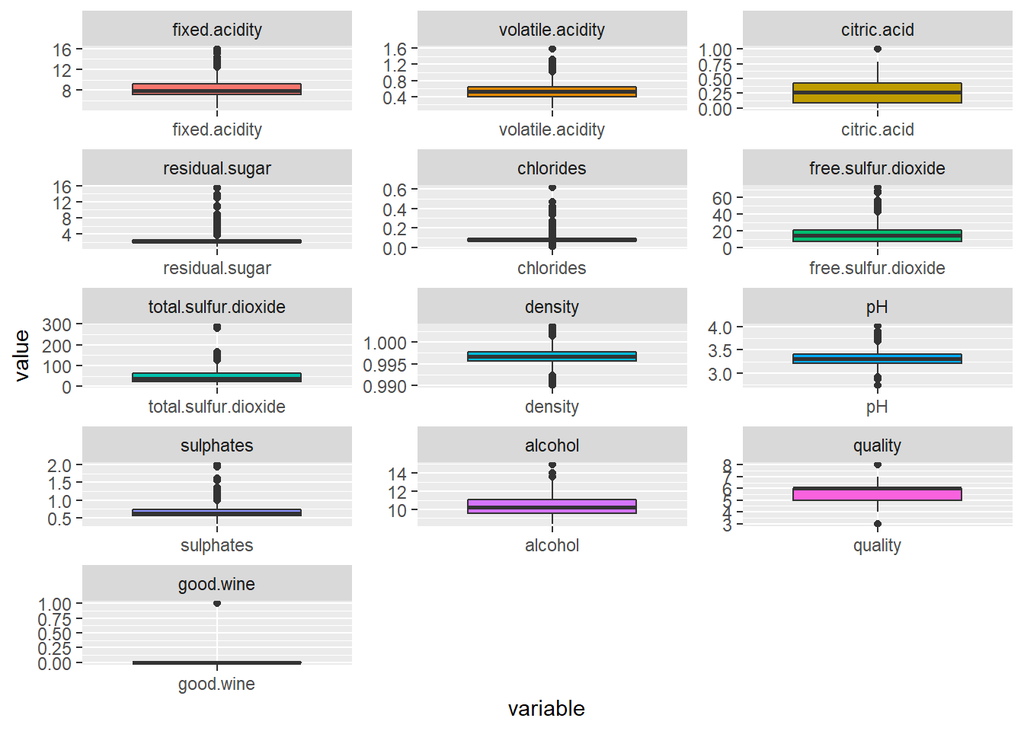

```r
ggplot(redwine3, aes(x=variable, y=value, fill=variable)) +
geom_boxplot() + facet_wrap(~variable, scales="free", ncol=3) +
theme(legend.position="none")
```

## Histogramas

```r
redwine4 <- melt(redwine)
```

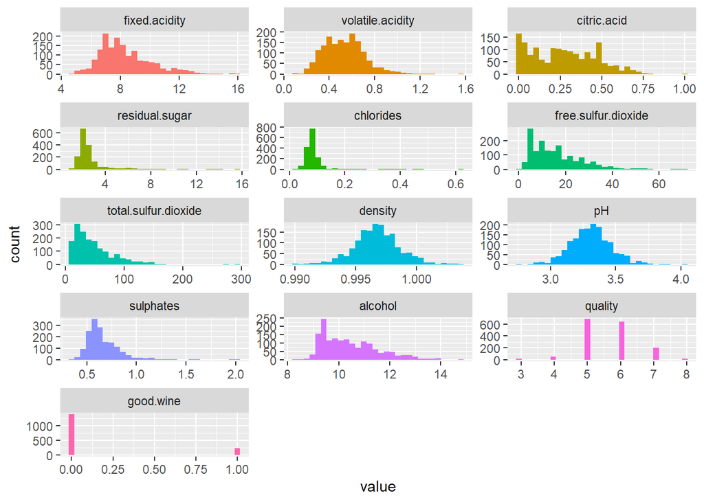

```r
ggplot(redwine4, aes(value, fill=variable)) + facet_wrap(~variable, scales = 'free', ncol=3) +  geom_histogram() + theme(legend.position="none")
```

## Alcohol vs Qualitat

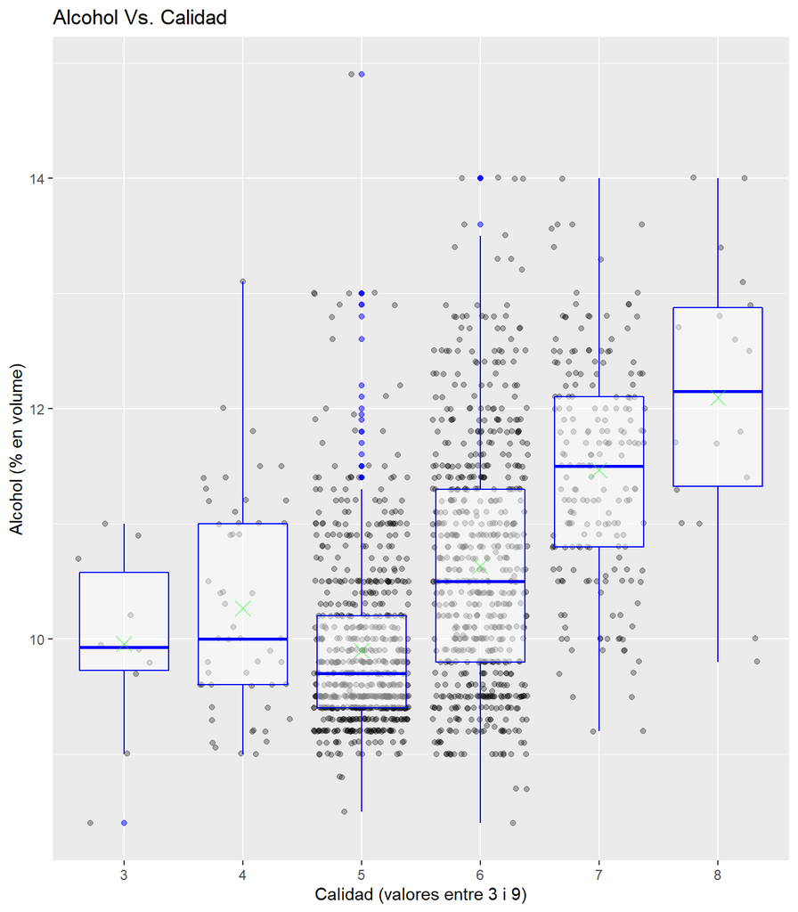

## Volatile acidity vs Calidiad

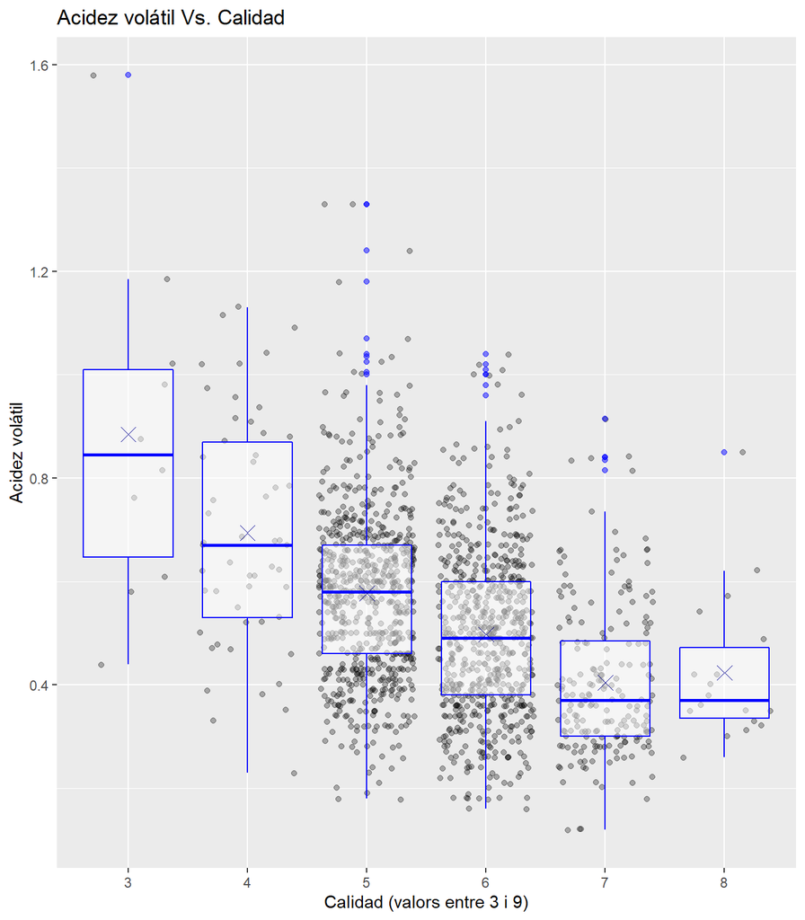

## Normalidad : Q-Q

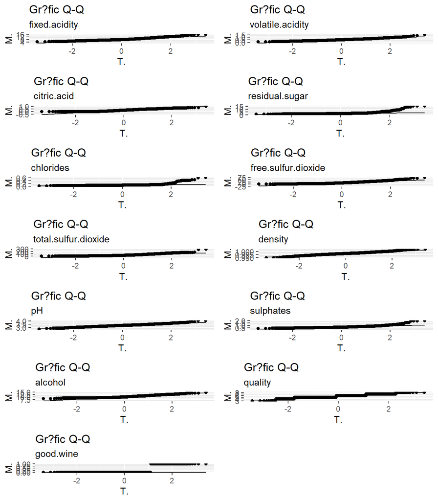

## Variancia : varainza segun los tipos de vino

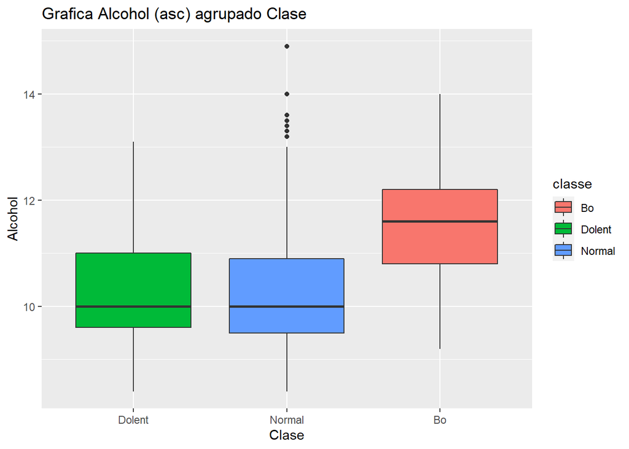

## PCA : Grafico que muestran la relación

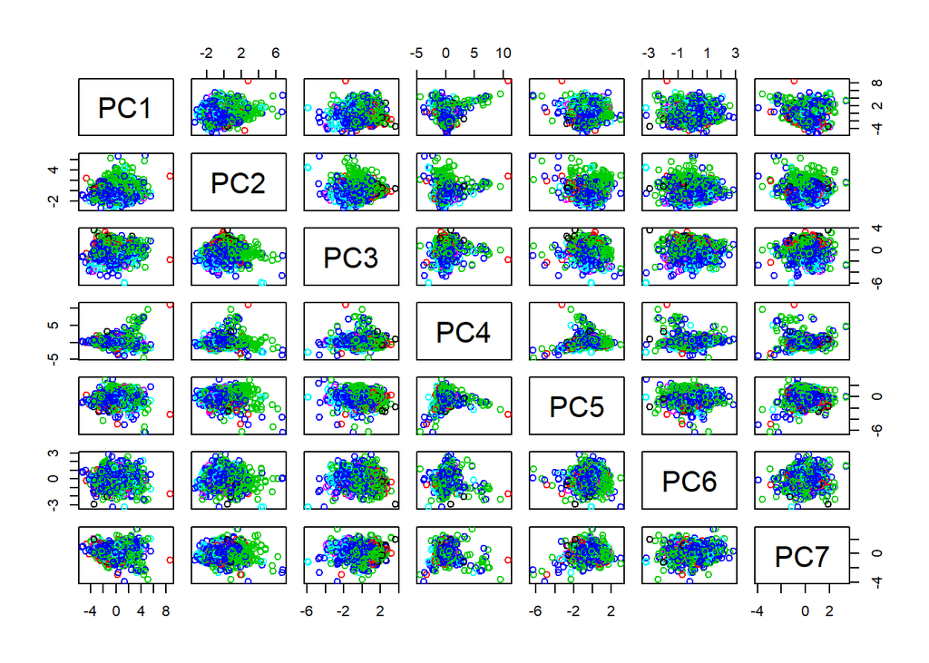

## PCA : graficos acumulado y parcial qu emuestra el % de la varianza

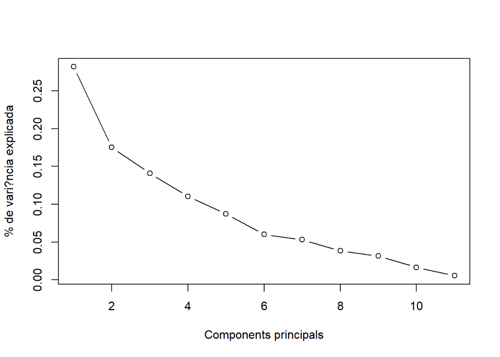

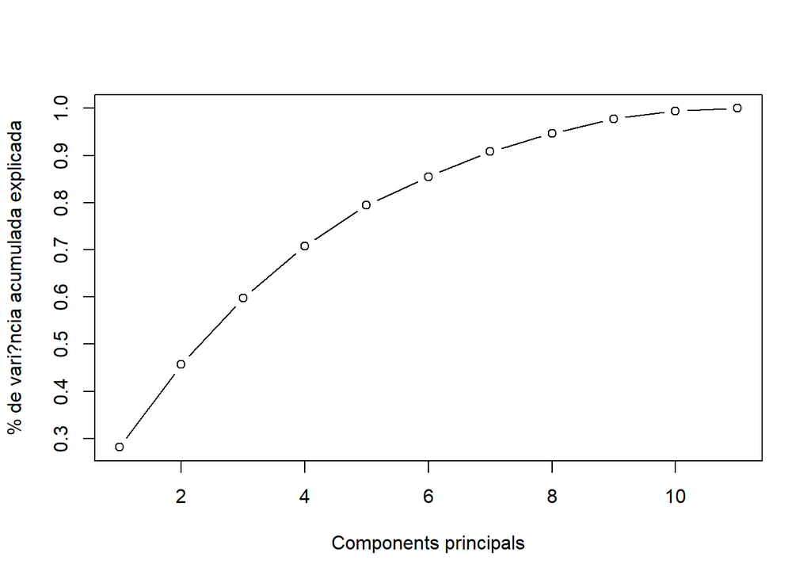

# 6. Resolucion del problema.

## A partir de los resultados obtenidos, ¿cuáles son las conclusiones? ¿Los resultados permiten responder al problema?

Con los resultados podemos decir

- la *regresion lineal* NO es un buen modelo. NO explica la calidad de un vino en funcionde los valore o atributos qu ehemso estudiado. Como hemos usado un valor subjetivo (**quality**) a partir de *valores objetivos* (alguna propiedd que se pueda medir). Seria mejor hacer una *discretitzacion* la calidad del vino en funcion de dos valore sbinarios (bueno=1, malo=0) y aplicar *regresion logistica*
- Per altra banda, el model de regressi? lineal probablement serviria per explicar, amb un cert grau de bondat, altres atributs, sense tenir en compte la qualitat.

# Bibliografia y referencias usadas

- Materials de l’assignatura ‘Tipolog?a i cicle de vida de les dades’, UOC
- Dataset de mostra : https://www.kaggle.com/uciml/red-wine-quality-cortez-et-al-2009
- https://stackoverflow.com/questions/49044753/scale-kable-table-to-fit-page-width
- https://www.uv.es/conesa/CursoR/material/
- https://www.rdocumentation.org/packages/utils/versions/3.6.2/topics/
- https://www.rstudio.com/wp-content/uploads/2015/02/rmarkdown-cheatsheet.pdf
- https://owi.usgs.gov/blog/boxplots/
- http://r-statistics.co/Top50-Ggplot2-Visualizations-MasterList-R-Code.html#Box%20Plot
- https://www.cyclismo.org/tutorial/R/pValues.html
- http://www.sthda.com
- http://r-statistics.co/Outlier-Treatment-With-R.html
- https://www.kaggle.com/tsilveira/wine-r/comments
- https://owi.usgs.gov/blog/boxplots/
- https://stackoverflow.com/questions/7196450/create-a-data-frame-of-unequal-lengths
- https://stackoverflow.com/questions/34004008/transposing-in-dplyr
- https://briatte.github.io/ggcorr/#controlling-the-main-geometry
- https://rpubs.com/Joaquin_AR/287787
- https://towardsdatascience.com
- https://tereom.github.io/est_computacional/01-Intro-R/R_analisis_datos_visualizacion

*** Otros trbajos preparado pero no terminados ##Analisis de las variables #Correlacion de Variables #Matriz de dispersion

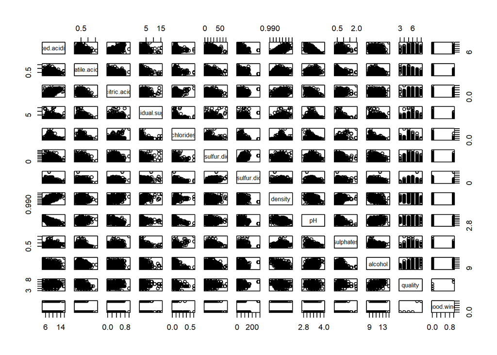

```r
plot(redwine)
```

# Visualizacion grafica de una matriz a color

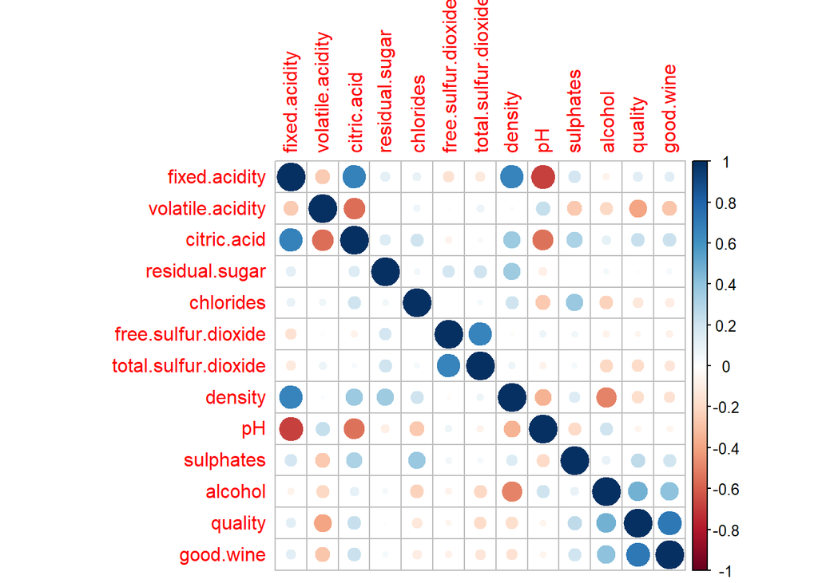

```r
#!!!
#corrplot (corr (redwine))
cor_redwine<-cor(redwine)
#cor_redwine
library(corrplot)
corrplot(cor_redwine,method = "circle")
```

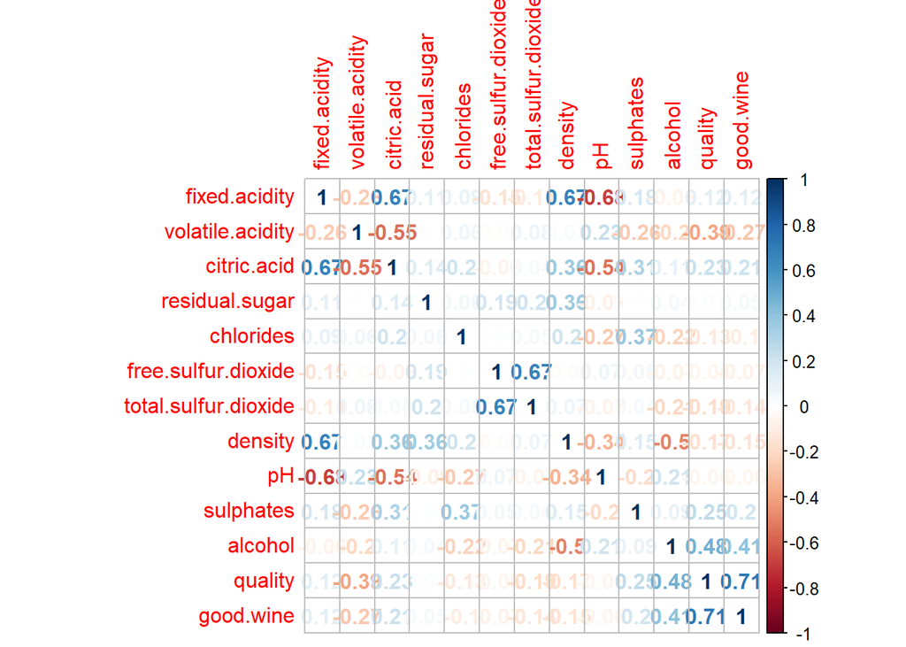

```r
corrplot(cor_redwine,method = "number")
```

```r
summary(redwine$quality)
```

```
##    Min. 1st Qu.  Median    Mean 3rd Qu.    Max.
##   3.000   5.000   6.000   5.636   6.000   8.000
```

### Distribución de las calificaciones de calidad del vino tinto

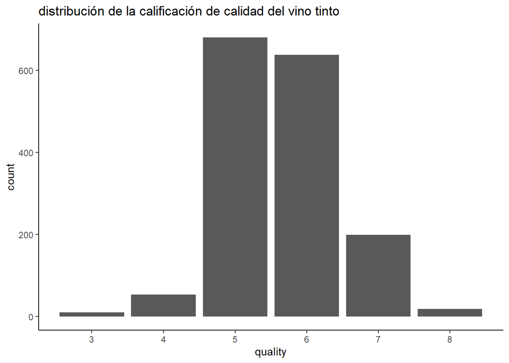

```r
library(ggplot2)

ggplot(redwine,aes(x=quality))+geom_bar(stat = "count",position = "dodge")+
  scale_x_continuous(breaks = seq(3,8,1))+
  ggtitle("distribución de la calificación de calidad del vino tinto")+
  theme_classic()
```

### Distribución de vinos tintos buenos o malos

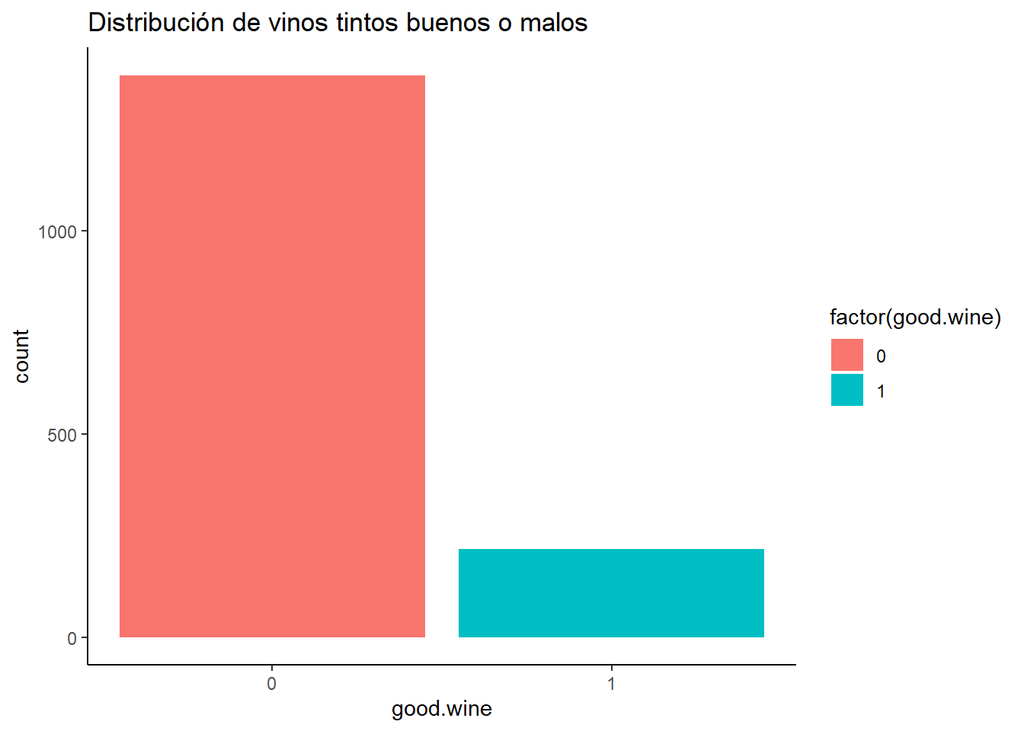

```r
ggplot(redwine,aes(x=good.wine,fill=factor(good.wine)))+geom_bar(stat = "count",position = "dodge")+
  scale_x_continuous(breaks = seq(0,1,1))+
  ggtitle("Distribución de vinos tintos buenos o malos")+
  theme_classic()
```